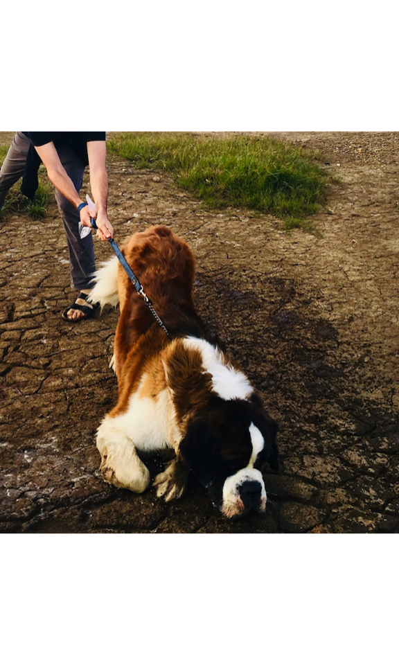

Banjo is a St. Bernard. He is 80kg is not easily kept out of water.

Suppose you would like to model how quickly St. Bernards grow from 0 to 12 months old and you have been given some data on age and weight of St. Bernards from a tutor who is very interested in large dogs. The data is contained in the `R` chunk below.

```r
age_months <- c(0.4, 2.3, 2.9,  4.5,  4.9,  7.9,  10.1, 11.5)
weight_kgs <- c(1.8, 7.1, 17.0, 20.4, 36.1, 55.2, 58.4, 77.1)
```

1. Plot the data in `R`.
2. Assuming their weight increases linearly, numerically estimate the model
   $$\text{weight}_{i} = \alpha + \beta~\text{age}_{i}$$
   using the least squares method by following the steps. Fix $\alpha = 1$, that is St. Bernards are assumed to be 1kg when born.
3. Define the least squares function to be optimised. It should take the parameter(s) and data as arguments.
2. Optimise the least squares function using `optim`, try using `method = "BFGS"`.
3. Plot the least squares fit against the data. You will need to extract the fit from the result of `optim`. Try using `object_name$par`.
4. Compare your answer to the linear model function (`lm`) in `R`. Why are the values of $\beta$ different? Based on this, what should you be cautious about when performing estimation on parameters?